# Trends in References to Statistical Capacity Development in Global Summits

The indicator 4a, developed in the context of the BAPS Logframe, measures the references in global summits to `statistical development` and/or `data gaps`. Developed in the context of the BAPS Logical Framework, this indicator reflects the progress towards the BAPS action area that aims to “ensure that outcomes of global summits and high-level forums specifically recognize the need for statistical capacity development” [see the BAPS document](http://www.paris21.org/sites/default/files/Busanactionplan_nov2011.pdf).

### Data Sources

#### Definition of global summits

A first step towards identifying the data source for this indicator is the definition of global summit. A summit is a meeting between heads of governments (The Oxford Dictionary). For a summit to be global, it must bring together governments from around the world.

Following this definition, global summits can be characterised by exchanges between the participating governments. The events closest to this definition are the G20 summits that bring together governments from the 20 major economies. The G20, while closely fitting the concept of a global summit, can be criticised for not being truly global as discussions are driven by a rather select group of governments.

The approach proposed here is therefore to focus on intergovernmental organisations whose members are composed of the widest possible set of sovereign states. At the global level, these are the United Nations and (for each sectorial focus) their Specialised Agencies, such as:

*FAO, IFAD, ILO, IMF, IMO, ITU, UNDP, UNESCO, UNIDO, WHO, World Bank, WMO, and WTO*

These agencies bring together countries from all member states to discuss and set norms and policies.

#### Use information from UN agencies to screen for global summits

##### List of global summits

A natural second step is the identification of suitable outcome documents from UN specialised agencies that cover global summits and related discussions. One option is to draw up an exhaustive list of global summits. Immediate concerns with this approach are that this list would change annually and some of the largest summits are only organised biannually, which would introduce a lot of undesirable variation in such a measure.

##### Output documents from UN agencies

The method proposed here is therefore to consider more frequent output documents from UN Specialised Agencies. The use of direct output from these agencies has two main advantages:

**a.** First, it covers all relevant sectors at a global level.

**b.** Second, and more crucially, this approach does not require the Secretariat to identify such events itself. Instead, the Secretariat can assume that agencies follow and report on topics discussed in the most relevant events in their sector.

An option of direct output from UN agencies, for example, is their websites’ content that can be captured through RSS feeds. However, not every site has an active RSS feed and some (e.g. the World Bank) have dozens of feeds to subscribe to.

It is thus proposed to use a standardised and frequent source of outcome documents: the official Twitter accounts of the agencies and their daily tweets, endorsements and retweets[^1]. Tweets are particularly suitable because they cover the most relevant sectors and are published in an easily accessible format on a daily basis. In addition, tweets are also restricted to fewer characters (140 in most cases), making them easy to analyse.

The proposed indicator uses thus data extracted from the twitter timelines of these UN specialised agencies to measure the extent to which global summits include reference to statistical capacity development and data gaps.

### Methodology

The methodology proceeds in four steps as follows.

**a.** In a first step, it extracts hashtags for the current year for the 15 UN Specialised Agencies as well as for 20 Statistical Agencies. The latter are taken from the website of the global partnership for sustainable development data (GPSDD). These include PARIS21, ODW, World Bank Data, FAO Stats, etc.

**b.** In a second step, the methodology creates a list of hashtags related to statistical development and data gaps. These are hashtags that occur at least three times[^2] more often in tweets of Statistical Agencies than they do for UN Specialised Agencies.

**c.** Next, we take the most frequent hashtags (the top 75%) and calculate the relative frequency of their occurrence for each of the 15 UN Specialised Agencies.

**d.** In the fourth step, we calculate the non-weighted average over these relative frequencies for the 15 UN Specialised Agencies.

**e.** Finally, we show the trending history of top 6 hashtags used by Stats agencies.

#### Extract hashtags

##### Twitter timelines

First, twitter timelines of 15 United Nation Specialised Agencies are downloaded to identify twitter hashtags related to statistical development that were used during global summits for the current year.

Then, the same process is used with 20 accounts that tweet exclusively about issues related to statistical capacity development, i.e. accounts of Statistics Think Tanks.

*Examples are*:

- ContactPARIS21
- OpenDataWatch
- worldbankdata
- FAOstatistics

*But not: WorldBank, FAO, etc.*

Hashtags used by Stats Think Tanks are for instance: `#SDGs`, `#SDG`, `#Data`, `#BigData`, `#DataRev`, `#DataRevolution`, `#OpenData`, `#Statistics`, `#PPPs`, `#GlobalGoals`, `#Post2015`, `#Development`, `#MDGs`, `#data4sdgs`

Major Stats Think Tanks are catalogued based on the [Global Partnership for sustainable development data’s website](http://www.data4sdgs.org/champions/). The database finally includes tweets from 15 UN agencies and 20 Stats Think Tanks, or approximately 40 000 tweets since 2016. Twitter has a restriction of 3200 tweets loaded by twitter account. We update timeline datasets of each agency’s every month to capture the activities of its account.

##### Identification of hashtags referring to statistical development or data gaps

After loading timelines of United Nation Specialised Agencies, we `extract hashtags`, id and date of creation of each tweet and create a data frame with these observations. All the information extracted from all the UN agencies’ tweets are compiled together in a unique dataframe. This exercise is repeated for Stats Think Tanks.

#### Spot references to statistical development using hashtags sequences

We thus consider a tweet to make reference to `statistical development` or `data gaps` if it contains hashtags from this **keyword list** related to statistical capacity building.

This keyword list was compiled and extended by comparing the odds ratio of hashtags used in the timelines of (A) **Stats Think Tanks** with those of (B) other **International Organisations**

Stats Hashtags are identified in a **two-stage process**:

**a.** First, the `frequencies of each hashtag` used by UN agencies is computed. This exercise is repeated for Stats Think Tank.

**b.** Secondly, a list of hashtags related to statistics is determined by comparing the `odds ratios` of hashtags.

- The odd ratio of one hashtag is the relative frequency of this hashtag among all tags used by Stats Think Tanks on the relative frequency of this hashtag in the twitter timelines of UN agency.
- Mathematically, this means:

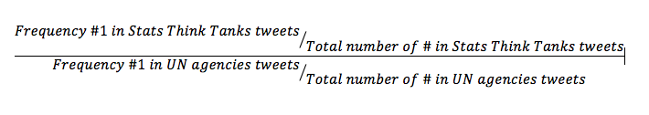

Odds ratios are cut from 3, so that we only keep the relevant hashtags in the UN agencies timelines that are in the 25 percentile in stats agencies odds ratios. Hashtags that occur at least three times more often in tweets of Stats Agencies than they do for UN Agencies are considered related to statistical capacity development. Table 1 shows the odds ratios of hashtags whose frequencies are larger than 10.

Table1: Frequency and odds of hashtags used by UN agencies.

| Hashtag | Frequency | Odds |
| --- | --- | --- |
| #data | 63 | 16.180250 |
| #sdg4 | 58 | 8.104335 |
| #education2030 | 54 | 3.972765 |
| #hlpf2016 | 37 | 4.025425 |
| #globaldev | 37 | 3.028301 |
| #sdg | 35 | 5.895163 |
| #bigdata | 34 | 8.560273 |
| #science | 31 | 4.231521 |
| #opendata | 26 | 99.749289 |
| #bees | 18 | 3.871548 |
| #dataviz | 17 | 37.456220 |
| #data4sdgs | 16 | 28.780403 |
| #wd2016 | 16 | 16.482545 |
| #sofia16 | 15 | 4.281476 |
| #rice | 14 | 3.220867 |
| #ods | 13 | 4.414616 |
| #canada | 12 | 4.099286 |
| #learning | 11 | 14.782273 |
| #culture | 11 | 4.099286 |

#### UN agencies tweets: Top hashtags related to statistics

Then, we take the most frequent hashtags (the top 75%) used by the 15 UN Specialised Agencies.The frequencies of these hashtags represented by size are illustrated in Figure 1.

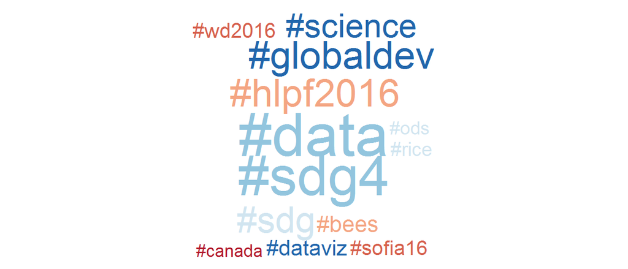

Figure 1: Frequencies of hashtags used by UN agencies represented by their size

Then, the *relative frequency of hashtags related to statistics* is computed for each UN agency, based on the hashtags identified during the first phase using odd ratios.

The relative frequency of hashtags related to statistical development for each agency is simply equal to the frequency of hashtags related to statistics used by each UN agencies over its total number of hashtags. Figure 2 compares the percentage of statistics-related hashtags tweeted by 15 agencies. The relative frequency of hashtags related to statistics is fairly low among all United Nation Specialised Agencies.

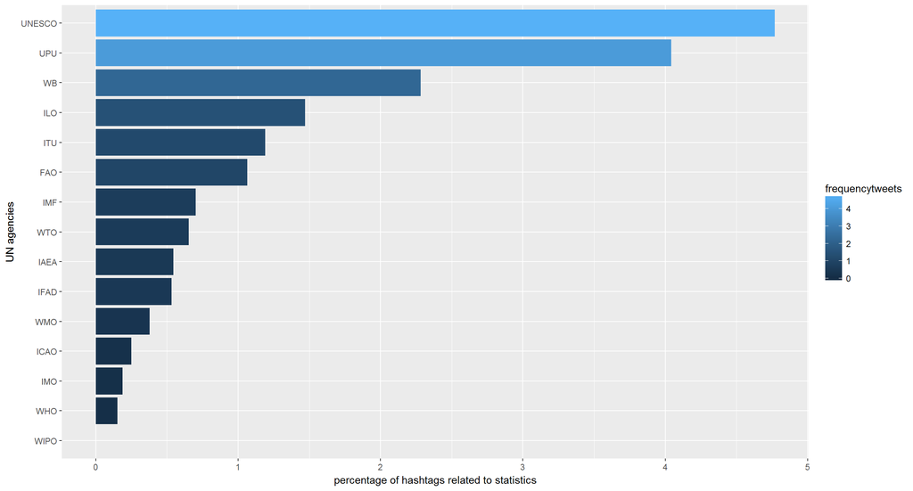

Figure 2: Relative frequency of hashtags related to statistics per agency

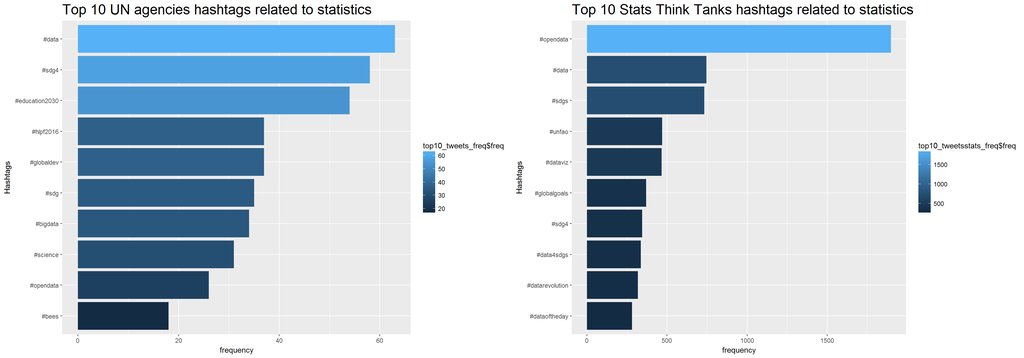

Figure 3: Comparison between UN agencies and Stats Think Tanks - Top 10 hashtags related to stats

#### Final indicator and initial results

An initial analysis was undertaken based on 38 100 unique tweets containing a total of 65 919 hashtags. The final indicator is the average over these relative frequencies for the 15 UN agencies. The relative frequency of tags related to statistical capacity development is currently at about 1,21%. It means that around 1.2% of all the hashtags used by all the UN agencies are related to statistical development and/or data gaps.

#### Trending of the top hashtags overtime

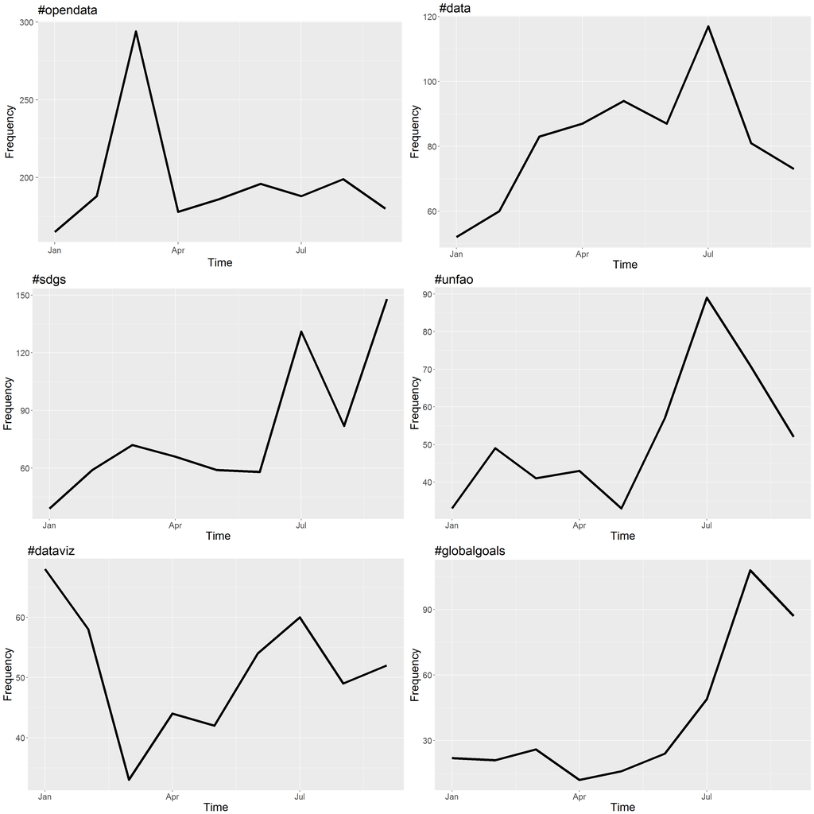

Figure 4: Trending of the top hashtags between January and September 2016

### Limitations

This methodology has several limitations.

**a.** Tweets are a non-representative data source made available by a private company. The methodology is therefore subject to biases and depends on continued access to the Twitter API, which may not be sustainable in the long term.

**b.** Difference between UN and country perspective: Although UN Specialised Agencies will by and large reflect the priorities of their member countries, they may not give a balanced view of the position of country’s heads of states.

**c.** Difference between frequency and impact of topics: Some topics may trend on Twitter and even induce herding behaviour among the agencies but do not make it on the agenda of high-level events.

**d.** Weighting of summits: Some summits do not really have an output but some others clearly have decisions. A future version of the methodology could aim to differentiate these and reflect this in the form of a weighting.

### Next Steps and Conclusion

This indicator 4a provides a unique measure of references in global summits to statistical development and/or data gaps. It identifies hashtags related to statistical development and computes the relative frequency of these stats hashtags per UN agency. It allows therefore to observe the relative weight of each United Nation Specialised Agency in the total number of references to statistical development in global summits.

As approved in the 2016 Board Meeting, the Secretariat will continue the fully automated data collection for the indicator using the Twitter API and by the 2018 Board Meeting, will have determined targets for monitoring beyond 2019.

As part of the implementation, the analysis will feed into the development of a *freely accessible, online-based results monitoring instrument* that allows users to track and browse outcomes of all global summits and high level forums.

[^1]: A retweet is a forward of individual tweets by other users to their own feed.
[^2]: This odds ratio of three turned out to be a good cut-off value.